# Cleaning

# 4 All Cause Female Reproductive age

Next we are going to clean this dataset so we may examine how all-cause deaths may differ from assault only. This will be important as deaths by assault are underreported and often misclassified. Let’s start by importing the data and applying the cleaning function for .csv’s.

```r
all_repro_f <- read.csv("../RawData/texas_allcause_female1544.csv")

all_repro_f <- clean.csv(all_repro_f)

head(all_repro_f)
```

```
##   Deaths month_year bill8 time
## 1    436 2018-01-01 FALSE    1
## 2    378 2018-02-01 FALSE    2
## 3    354 2018-03-01 FALSE    3
## 4    336 2018-04-01 FALSE    4
## 5    380 2018-05-01 FALSE    5
## 6    355 2018-06-01 FALSE    6
```

Let’s check out the data:

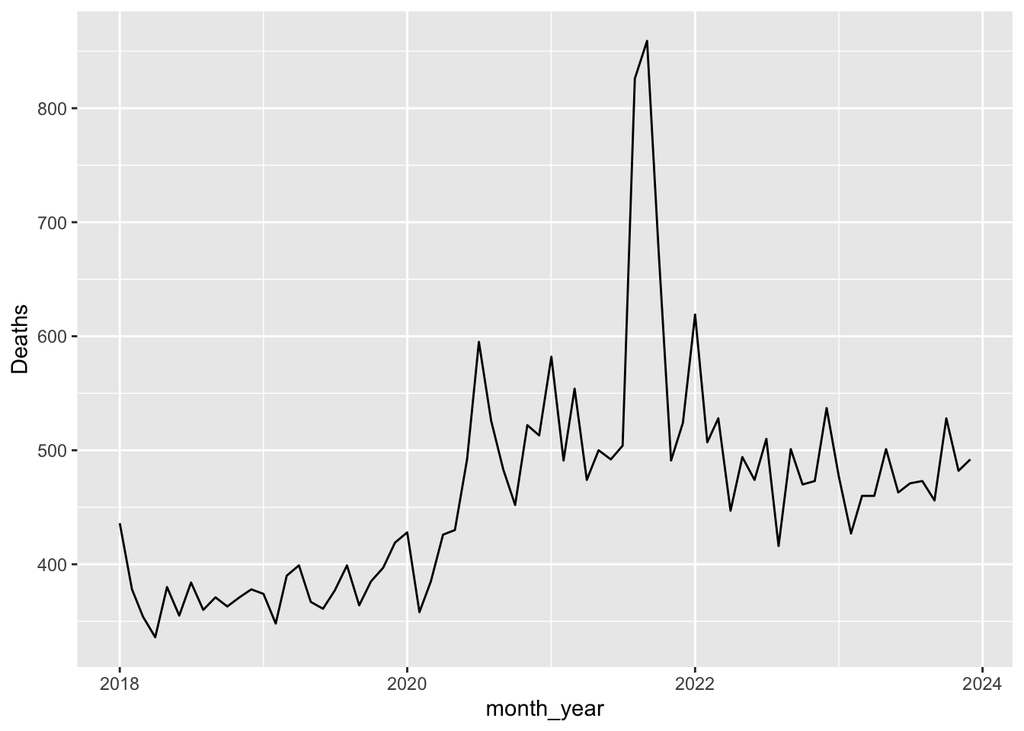

```r
ggplot(all_repro_f, aes(month_year, Deaths))+
  geom_line()
```

Looks good! Let’s save the all cause female data to our cleaned folder.

```r
write_csv(all_repro_f, "../CleanData/all_cause_repro_f.csv")
```

Males this time:

```r
all_repro_m <- read.csv("../RawData/texas_allcause_male1544.csv")
glimpse(all_repro_m)
```

```
## Rows: 142
## Columns: 8
## $ Notes                                    <chr> "", "", "", "", "", "", "", "…
## $ Month                                    <chr> "Jan., 2018", "Feb., 2018", "…
## $ Month.Code                               <chr> "2018/01", "2018/02", "2018/0…
## $ Deaths                                   <int> 899, 726, 759, 741, 810, 835,…
## $ Population                               <chr> "Not Applicable", "Not Applic…
## $ Crude.Rate                               <chr> "Not Applicable", "Not Applic…
## $ Crude.Rate.Lower.95..Confidence.Interval <chr> "Not Applicable", "Not Applic…
## $ Crude.Rate.Upper.95..Confidence.Interval <chr> "Not Applicable", "Not Applic…
```

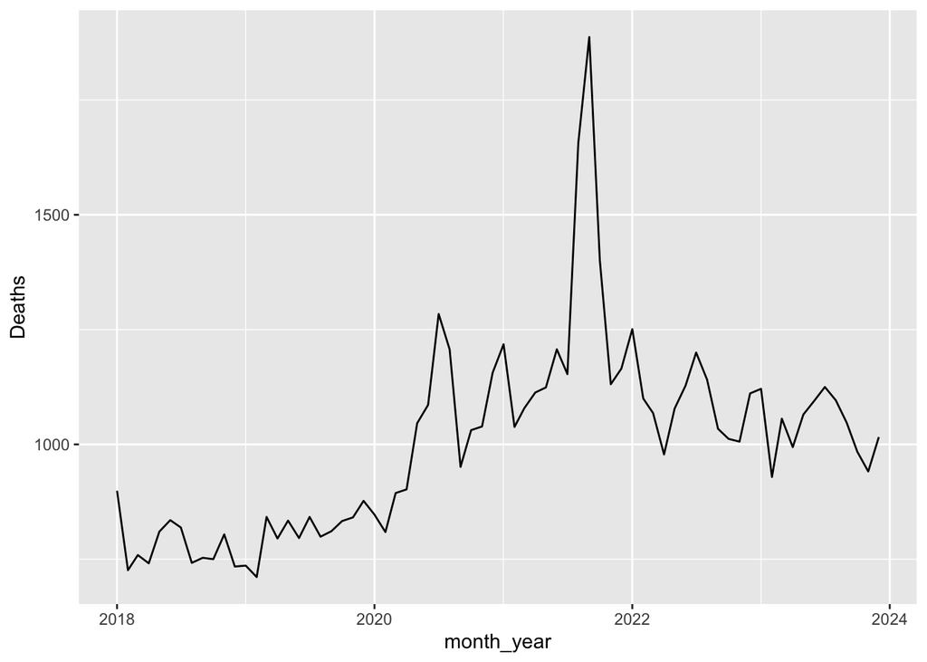

```r
all_repro_m <- all_repro_m %>%
  mutate(month_year = my(Month)) %>%
  select(-Month, -Month.Code, -Notes,-Population:-Crude.Rate.Upper.95..Confidence.Interval) %>%
  filter(month_year < "2024-01-01") %>%
  mutate( time = row_number ())


ggplot(all_repro_m, aes(month_year, Deaths))+
  geom_line()
```

```r
write_csv(all_repro_m, "../CleanData/all_cause_repro_m.csv")
```

# 5 Assault all age female

Next we are going to clean the data for all ages female, cod by assault.

```r
all_age_f_assault <- read_excel("../RawData/All_Ages_Female.xlsx")
all_age_f_assault <- clean.xcel(all_age_f_assault)
head(all_age_f_assault)
```

```
## # A tibble: 6 × 4
##   Deaths month_year bill8  time
##    <dbl> <date>     <lgl> <int>
## 1     29 2018-01-01 FALSE     1
## 2     26 2018-02-01 FALSE     2
## 3     30 2018-03-01 FALSE     3
## 4     31 2018-04-01 FALSE     4
## 5     33 2018-05-01 FALSE     5
## 6     23 2018-06-01 FALSE     6
```

```r
all_age_m_assault <- read.csv("../RawData/all_age_assault_male.csv")
all_age_m_assault <- all_age_m_assault %>%
   mutate(month_year = my(Month)) %>%
  select(-Month, -Month.Code, -Notes,-Population:-Crude.Rate.Upper.95..Confidence.Interval) %>%
  filter(month_year < "2024-01-01") %>%
  mutate( time = row_number ())

write_csv(all_age_m_assault, "../CleanData/all_age_m_assault.csv")
```

Same as before, let’s briefly check out what the data looks like:

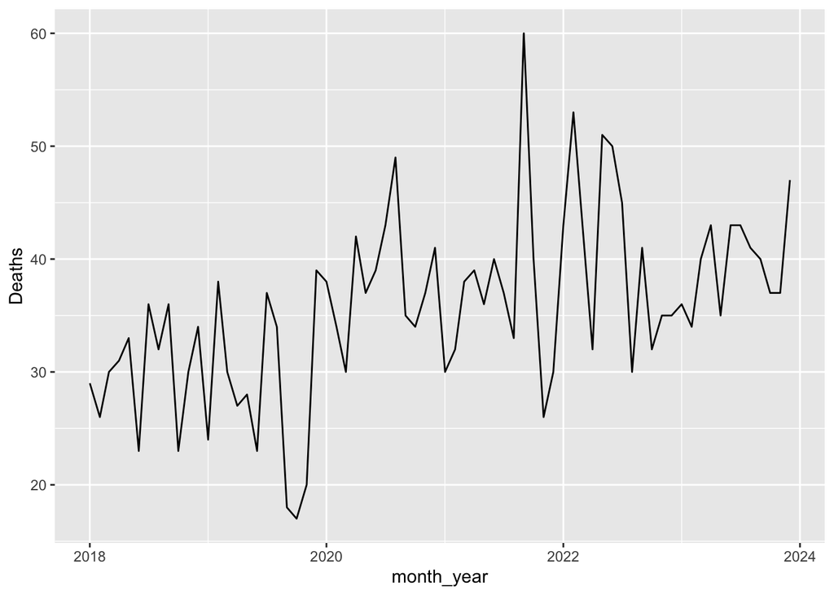

```r
ggplot(all_age_f_assault, aes(month_year, Deaths))+
  geom_line()
```

Let’s write our csv:

```r
write_csv(all_age_f_assault, "../CleanData/all_age_f_assault.csv")
```

# 6 Age 15+

Let’s also check out the data for texas deaths by assault, this time just with ages 15+.

```r
assault_15_plus <- read_excel("../RawData/assault_15_plus.xlsx")
assault_15_plus <- clean.xcel(assault_15_plus)
head(assault_15_plus)
```

```
## # A tibble: 6 × 4
##   Deaths month_year bill8  time
##    <dbl> <date>     <lgl> <int>
## 1     16 2018-01-01 FALSE     1
## 2     16 2018-02-01 FALSE     2
## 3     17 2018-03-01 FALSE     3
## 4     26 2018-04-01 FALSE     4
## 5     17 2018-05-01 FALSE     5
## 6     11 2018-06-01 FALSE     6
```

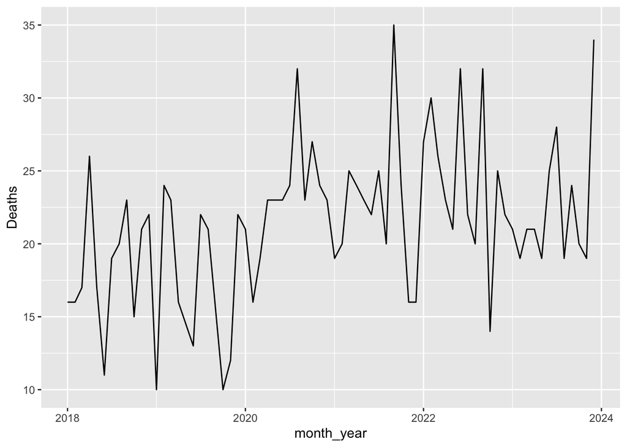

```r
ggplot(assault_15_plus, aes(month_year, Deaths))+
  geom_line()
```

```r
write_csv(assault_15_plus, "../CleanData/assault_15_plus")
```

# 7 National control set

This time we are going to pull ages 15-44 deaths by assault nationally.

```r
nat_f_assault <- read_excel("../RawData/national_f_assault.xlsx")
nat_f_assault <- clean.xcel(nat_f_assault)
head(nat_f_assault)
```

```
## # A tibble: 6 × 6
##   Deaths Crude Rate Lower 95% Co…¹ Crude Rate Upper 95%…² month_year bill8  time
##    <dbl> <chr>                     <chr>                  <date>     <lgl> <int>
## 1    194 Not Applicable            Not Applicable         2018-01-01 FALSE     1
## 2    149 Not Applicable            Not Applicable         2018-02-01 FALSE     2
## 3    170 Not Applicable            Not Applicable         2018-03-01 FALSE     3
## 4    183 Not Applicable            Not Applicable         2018-04-01 FALSE     4
## 5    165 Not Applicable            Not Applicable         2018-05-01 FALSE     5
## 6    182 Not Applicable            Not Applicable         2018-06-01 FALSE     6
## # ℹ abbreviated names: ¹`Crude Rate Lower 95% Confidence Interval`,
## #   ²`Crude Rate Upper 95% Confidence Interval`
```

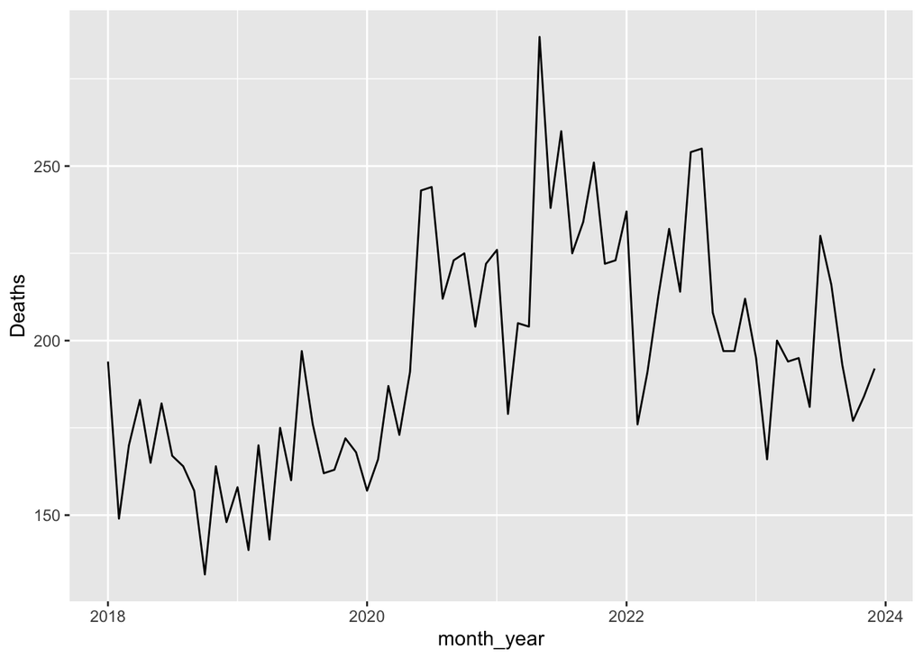

```r
ggplot(nat_f_assault, aes(month_year, Deaths))+
  geom_line()
```

```r
write_csv(nat_f_assault, "../CleanData/nat_f_assault.csv")
```

# 8 Disaggregated Race

We pulled the deaths for assault and all-cause, but we are just going to focus on all-cause to increase power.

```r
h <- read.csv("../RawData/RacialDisaggregation/All_cause/H.csv")
nh <- read.csv("../RawData/RacialDisaggregation/All_cause/NH.csv")


racial <- clean_racial(nh,h)
write_csv(racial, "../CleanData/racial_all_cause.csv")
```

# 9 COVID Deaths

We need to clean the data with deaths attributed to COVID so we may create an all-cause minus COVID mortality dataset.

Starting with pulling up the COVID mortality data (female reproductive age):

```r
covid <- read.csv("../RawData/COVID/COVID.csv")
#checking import
glimpse(covid)
```

```
## Rows: 144
## Columns: 8
## $ Notes                                    <chr> "", "", "", "", "", "", "", "…
## $ Month                                    <chr> "Jan., 2018", "Feb., 2018", "…
## $ Month.Code                               <chr> "2018/01", "2018/02", "2018/0…
## $ Deaths                                   <chr> "0", "0", "0", "0", "0", "0",…
## $ Population                               <chr> "Not Applicable", "Not Applic…
## $ Crude.Rate                               <chr> "Not Applicable", "Not Applic…
## $ Crude.Rate.Lower.95..Confidence.Interval <chr> "Not Applicable", "Not Applic…
## $ Crude.Rate.Upper.95..Confidence.Interval <chr> "Not Applicable", "Not Applic…
```

We have quite a few days where the death value is suppressed.

```r
covid %>%
  filter(Deaths == "Suppressed") %>%
  select(Month)
```

```
##                                   Month
## 1                            Mar., 2020
## 2                            Apr., 2022
## 3                            Jun., 2022
## 4                            Sep., 2022
## 5                            Oct., 2022
## 6                            Nov., 2022
## 7                            Mar., 2023
## 8                            Apr., 2023
## 9                             May, 2023
## 10                           Jun., 2023
## 11                           Jul., 2023
## 12                           Aug., 2023
## 13                           Sep., 2023
## 14                           Oct., 2023
```

[output cut: 21 more lines]

```r
#Need to change suppressed values to be 0s and make deaths numeric.
covid <- covid %>%
    mutate(Deaths = as.numeric(na_if(Deaths, "Suppressed")),
          month_year = my(Month)) %>%
  select(-Notes,-Month, -"Month.Code", -Population:-"Crude.Rate.Upper.95..Confidence.Interval") %>%
  filter(month_year < "2024-01-01") %>%
  mutate(time = row_number ())
```

Next, we will create new COD variables so when we delete the deaths from all cause we can match up accordingly:

```r
covid <- covid %>%
  mutate(cod = "covid")

all_repro_f <- all_repro_f %>%
  mutate(cod = "all_cause")

#checking if dates are the same:
identical(
  sort(unique(covid$month_year)),
  sort(unique(all_repro_f$month_year))
)
```

```
## [1] TRUE
```

```r
#finding dates missing
setdiff(covid$month_year, all_repro_f$month_year)
```

```
## Date of length 0
```

```r
setdiff(all_repro_f$month_year, covid$month_year)
```

```
## Date of length 0
```

```r
combined <- all_repro_f %>%
  left_join(covid,
            by = c("month_year"),
            suffix = c("_all", "_covid"))

#subtracting deaths, making NA deaths 0
all_cause_minus_covid <- combined %>%
  mutate(
    Deaths = Deaths_all - coalesce(Deaths_covid, 0)
  ) %>%
  select(month_year, Deaths)

head(all_cause_minus_covid)
```

```
##   month_year Deaths
## 1 2018-01-01    436
## 2 2018-02-01    378
## 3 2018-03-01    354
## 4 2018-04-01    336
## 5 2018-05-01    380
## 6 2018-06-01    355
```

```r
#checking that we have every month!
full_dates <- seq.Date(
  from = as.Date("2018-01-01"),
  to   = as.Date("2023-12-01"),
  by   = "month"
)

missing_dates <- setdiff(full_dates, all_cause_minus_covid$month_year)

missing_dates
```

```
## Date of length 0
```

After creating our all cause minus covid, it looks as though we have successfully subtracted all and preserved all the dates in our study period. We can now save this cleaned dataset.

```r
write_csv(all_cause_minus_covid, "../CleanData/all_cause_minus_covid.csv")
```

## 9.1 Racial Disag

```r
h_covid <- read.csv("../RawData/RacialDisaggregation/COVID/H.csv")
nh_covid <- read.csv("../RawData/RacialDisaggregation/COVID/NH.csv")
head(h_covid)
```

```
##   Notes      Month Month.Code Deaths     Population     Crude.Rate
## 1       Jan., 2018    2018/01      0 Not Applicable Not Applicable
## 2       Feb., 2018    2018/02      0 Not Applicable Not Applicable
## 3       Mar., 2018    2018/03      0 Not Applicable Not Applicable
## 4       Apr., 2018    2018/04      0 Not Applicable Not Applicable
## 5        May, 2018    2018/05      0 Not Applicable Not Applicable
## 6       Jun., 2018    2018/06      0 Not Applicable Not Applicable
##   Crude.Rate.Lower.95..Confidence.Interval
## 1                           Not Applicable
## 2                           Not Applicable
## 3                           Not Applicable
## 4                           Not Applicable
## 5                           Not Applicable
## 6                           Not Applicable
##   Crude.Rate.Upper.95..Confidence.Interval
## 1                           Not Applicable
## 2                           Not Applicable
## 3                           Not Applicable
## 4                           Not Applicable
## 5                           Not Applicable
## 6                           Not Applicable
```

```r
head(nh_covid)
```

```
##   Notes      Month Month.Code                             Single.Race.6
## 1       Jan., 2018    2018/01          American Indian or Alaska Native
## 2       Jan., 2018    2018/01                                     Asian
## 3       Jan., 2018    2018/01                 Black or African American
## 4       Jan., 2018    2018/01 Native Hawaiian or Other Pacific Islander
## 5       Jan., 2018    2018/01                                     White
## 6       Jan., 2018    2018/01                        More than one race
##   Single.Race.6.Code Deaths     Population     Crude.Rate
## 1             1002-5      0 Not Applicable Not Applicable
## 2                  A      0 Not Applicable Not Applicable
## 3             2054-5      0 Not Applicable Not Applicable
## 4              NHOPI      0 Not Applicable Not Applicable
## 5             2106-3      0 Not Applicable Not Applicable
## 6                  M      0 Not Applicable Not Applicable
##   Crude.Rate.Lower.95..Confidence.Interval
## 1                           Not Applicable
## 2                           Not Applicable
## 3                           Not Applicable
## 4                           Not Applicable
## 5                           Not Applicable
## 6                           Not Applicable
##   Crude.Rate.Upper.95..Confidence.Interval
## 1                           Not Applicable
## 2                           Not Applicable
## 3                           Not Applicable
## 4                           Not Applicable
## 5                           Not Applicable
## 6                           Not Applicable
```

```r
racial_covid <- clean_racial(nh_covid,h_covid)
head(racial_covid)
```

```
##                           race_eth Deaths month_year
## 1 American Indian or Alaska Native     NA 2018-01-01
## 2 American Indian or Alaska Native     NA 2018-02-01
## 3 American Indian or Alaska Native     NA 2018-03-01
## 4 American Indian or Alaska Native     NA 2018-04-01
## 5 American Indian or Alaska Native     NA 2018-05-01
## 6 American Indian or Alaska Native     NA 2018-06-01
```

```r
racial_covid <- racial_covid %>%
  mutate(cod = "covid") %>%
  filter(!race_eth %in% c("Native Hawaiian or Other Pacific Islander", "American Indian or Alaska Native"))

h <- read.csv("../RawData/RacialDisaggregation/All_cause/H.csv")
nh <- read.csv("../RawData/RacialDisaggregation/All_cause/NH.csv")
racial <- clean_racial(nh,h)
head(racial)
```

```
##                           race_eth Deaths month_year
## 1 American Indian or Alaska Native     NA 2018-01-01
## 2 American Indian or Alaska Native     NA 2018-07-01
## 3 American Indian or Alaska Native     NA 2018-08-01
## 4 American Indian or Alaska Native     NA 2018-10-01
## 5 American Indian or Alaska Native     NA 2018-11-01
## 6 American Indian or Alaska Native     NA 2019-01-01
```

```r
#cleaning the two datasets:
racial <- racial %>%
  filter(!race_eth %in% c("Native Hawaiian or Other Pacific Islander", "American Indian or Alaska Native")) %>%
  mutate(cod = "all_cause")

head(racial_covid)
```

```
##   race_eth Deaths month_year   cod
## 1    Asian     NA 2018-01-01 covid
## 2    Asian     NA 2018-02-01 covid
## 3    Asian     NA 2018-03-01 covid
## 4    Asian     NA 2018-04-01 covid
## 5    Asian     NA 2018-05-01 covid
## 6    Asian     NA 2018-06-01 covid
```

```r
head(racial)
```

```
##   race_eth Deaths month_year       cod
## 1    Asian     14 2018-02-01 all_cause
## 2    Asian     10 2018-07-01 all_cause
## 3    Asian     12 2018-09-01 all_cause
## 4    Asian     10 2018-11-01 all_cause
## 5    Asian     12 2018-12-01 all_cause
## 6    Asian     12 2019-01-01 all_cause
```

```r
#checking if dates are the same:
identical(
  sort(unique(racial_covid$month_year)),
  sort(unique(racial$month_year))
)
```

```
## [1] TRUE
```

```r
#combining
combined_racial <- racial %>%
  left_join(racial_covid, by = c("month_year", "race_eth"),
            suffix = c("_all", "_covid"))

#subtracting deaths, making NA deaths 0
racial_minus_covid <- combined_racial %>%
  mutate(
    Deaths = Deaths_all - coalesce(Deaths_covid, 0)
  ) %>%
  select(race_eth, month_year, Deaths)

head(racial_minus_covid)
```

```
##   race_eth month_year Deaths
## 1    Asian 2018-02-01     14
## 2    Asian 2018-07-01     10
## 3    Asian 2018-09-01     12
## 4    Asian 2018-11-01     10
## 5    Asian 2018-12-01     12
## 6    Asian 2019-01-01     12
```

```r
#checking that we have every month!
full_dates <- seq.Date(
  from = as.Date("2018-01-01"),
  to   = as.Date("2023-12-01"),
  by   = "month"
)

missing_dates <- setdiff(full_dates, racial_minus_covid$month_year)

missing_dates
```

```
## Date of length 0
```

```r
write_csv(racial_minus_covid, "../CleanData/racial_minus_covid.csv")
```

### 9.1.1 Annual

We are going to look at annual trends in terms of assault deaths for repro-age females, just in case there’s something to be said there.

```r
h_assault <- read.csv("../RawData/RacialDisaggregation/Assault/Annual/H.csv")
nh_assault <- read.csv("../RawData/RacialDisaggregation/Assault/Annual/NH.csv")
head(h_assault)
```

```
##   Notes Year Year.Code Deaths Population Crude.Rate
## 1       2018      2018     89    2550647        3.5
## 2       2019      2019     76    2584352        2.9
## 3       2020      2020     98    2624855        3.7
## 4       2021      2021    100    2654764        3.8
## 5       2022      2022    107    2718383        3.9
## 6       2023      2023    117    2733117        4.3
##   Crude.Rate.Lower.95..Confidence.Interval
## 1                                      2.8
## 2                                      2.3
## 3                                      3.0
## 4                                      3.0
## 5                                      3.2
## 6                                      3.5
##   Crude.Rate.Upper.95..Confidence.Interval
## 1                                      4.3
## 2                                      3.7
## 3                                      4.5
## 4                                      4.5
## 5                                      4.7
## 6                                      5.1
```

```r
head(nh_assault)
```

```
##   Notes Year Year.Code                             Single.Race.6
## 1       2018      2018          American Indian or Alaska Native
## 2       2018      2018                                     Asian
## 3       2018      2018                 Black or African American
## 4       2018      2018 Native Hawaiian or Other Pacific Islander
## 5       2018      2018                                     White
## 6       2019      2019          American Indian or Alaska Native
##   Single.Race.6.Code     Deaths Population Crude.Rate
## 1             1002-5          0      18913        0.0
## 2                  A Suppressed     349407 Suppressed
## 3             2054-5         73     786516        9.3
## 4              NHOPI          0       6134        0.0
## 5             2106-3         53    2173079        2.4
## 6             1002-5          0      19128        0.0
##   Crude.Rate.Lower.95..Confidence.Interval
## 1                                      0.0
## 2                               Suppressed
## 3                                      7.3
## 4                                      0.0
## 5                                      1.8
## 6                                      0.0
##   Crude.Rate.Upper.95..Confidence.Interval
## 1                                      0.0
## 2                               Suppressed
## 3                                     11.7
## 4                                      0.0
## 5                                      3.2
## 6                                      0.0
```

```r
unique(nh_assault$Year)
```

```
##  [1] "2018"                           "2019"
##  [3] "2020"                           "2021"
##  [5] "2022"                           "2023"
##  [7] "2024"                           "2025 (provisional)"
##  [9] "2026 (provisional and partial)" ""
```

```r
unique(h_assault$Year)
```

```
##  [1] "2018"                           "2019"
##  [3] "2020"                           "2021"
##  [5] "2022"                           "2023"
##  [7] "2024"                           "2025 (provisional)"
##  [9] "2026 (provisional and partial)" ""
```

```r
racial_assault <- clean_racial_annual(nh_assault,h_assault)


head(racial_assault)
```

```
##   year                         race_eth deaths
## 1 2018 American Indian or Alaska Native      0
## 2 2019 American Indian or Alaska Native      0
## 3 2020 American Indian or Alaska Native      0
## 4 2021 American Indian or Alaska Native      0
## 5 2022 American Indian or Alaska Native     NA
## 6 2023 American Indian or Alaska Native     NA
```

```r
racial_assault %>%
  group_by(race_eth) %>%
  filter(is.na(deaths))
```

```
## # A tibble: 9 × 3
## # Groups:   race_eth [2]
##    year race_eth                         deaths
##   <dbl> <chr>                             <dbl>
## 1  2022 American Indian or Alaska Native     NA
## 2  2023 American Indian or Alaska Native     NA
## 3  2018 Asian                                NA
## 4  2019 Asian                                NA
## 5  2020 Asian                                NA
## 6  2021 Asian                                NA
## 7  2022 Asian                                NA
## 8  2023 Asian                                NA
## 9  2024 Asian                                NA
```

```r
#missing too much info for Asian and American Indian/Alaska Native, excluding those from df

racial_assault <- racial_assault %>%
  filter(!race_eth %in% c("American Indian or Alaska Native", "Asian"))

write.csv(racial_assault, "../CleanData/racial_assault_annual.csv")
```